# 9주차과제-201612063

관심있는 주제에 대한 텍스트 파일 수집

제가 존경하고 관심있는 인물인 페이스북 창업자이자 최고 경영자(ceo)인 마크 저커버그가 2017년 하버드 대학에서 졸업식 축사를 진행했습니다. 마크 저커버그의 대학 졸업 연설문에 대해 텍스트 파일을 수집하였습니다.

```python
import nltk
nltk.download('punkt')
nltk.download('webtext')
nltk.download('wordnet')
nltk.download('stopwords')
nltk.download('averaged_perceptron_tagger')
```

```
True
```

```python
import pandas as pd
doc_speech=pd.read_table("book.txt")
```

```python
doc_speech=open('book.txt',mode='rt',encoding='utf-8').read()
print(len(doc_speech))
```

```
19886
```

```python
doc_speech
```

```
'\ufeffPresident Faust, Board of Overseers, faculty, alumni, friends, proud parents, members of the ad board, and graduates of the greatest university in the world,\n\n I\'m honored to be with you today because, let\'s face it, you accomplished something I never could. If I get through this speech, …
```

```python
print(doc_speech[:500])
```

```
President Faust, Board of Overseers, faculty, alumni, friends, proud parents, members of the ad board, and graduates of the greatest university in the world,

 I'm honored to be with you today because, let's face it, you accomplished something I never could. If I get through this speech, it'll be the first time I actually finish something at Harvard. Class of 2017, congratulations!

 I'm an unlikely speaker, not just because I dropped out, but because we're technically in the same generation. W
```

토크나이즈, 불용어 처리 등의 전처리 포함

```python
from nltk.tokenize import word_tokenize

tokens_speech=word_tokenize(doc_speech)
print(len(doc_speech))
print(tokens_speech[:900])
```

```
19886
['\ufeffPresident', 'Faust', ',', 'Board', 'of', 'Overseers', ',', 'faculty', ',', 'alumni', ',', 'friends', ',', 'proud', 'parents', ',', 'members', 'of', 'the', 'ad', 'board', ',', 'and', 'graduates', 'of', 'the', 'greatest', 'university', 'in', 'the', 'world', ',', 'I', "'m", 'honored', 'to', 'be…
```

```python
from nltk.tokenize import RegexpTokenizer
tokenizer = RegexpTokenizer("[\w']{3,}")

reg_tokens_speech = tokenizer.tokenize(doc_speech.lower())
print('#Num of tokens with RegexpTokenizer:', len(reg_tokens_speech))
print('#Token sample:')
print(reg_tokens_speech[:20])
```

```
#Num of tokens with RegexpTokenizer: 2759
#Token sample:
['president', 'faust', 'board', 'overseers', 'faculty', 'alumni', 'friends', 'proud', 'parents', 'members', 'the', 'board', 'and', 'graduates', 'the', 'greatest', 'university', 'the', 'world', "i'm"]
```

```python
from nltk.corpus import stopwords
english_stops = set(stopwords.words('english'))

result_speech = [word for word in reg_tokens_speech if word not in english_stops]

print('#Num of tokens after stopword elimination:', len(result_speech))
print('#Token sample:')
print(result_speech[:20])
```

```
#Num of tokens after stopword elimination: 1775
#Token sample:
['president', 'faust', 'board', 'overseers', 'faculty', 'alumni', 'friends', 'proud', 'parents', 'members', 'board', 'graduates', 'greatest', 'university', 'world', "i'm", 'honored', 'today', "let's", 'face']
```

단어 빈도 세기

```python
speech_word_count = dict()
for word in result_speech:
    speech_word_count[word] = speech_word_count.get(word, 0) + 1

print('#Num of used words:', len(speech_word_count))

sorted_word_count = sorted(speech_word_count, key=speech_word_count.get, reverse=True)

print("#Top 20 high frequency words:")
for key in sorted_word_count[:20]:
    print(f'{repr(key)}: {speech_word_count[key]}', end=', ')
```

```
#Num of used words: 837
#Top 20 high frequency words:
'people': 28, 'purpose': 27, 'one': 24, 'world': 21, 'everyone': 19, 'know': 19, 'get': 18, 'time': 16, 'sense': 15, 'generation': 13, 'today': 12, 'going': 12, 'create': 12, 'first': 11, "i'm": 10, "we're": 10, 'many': 10, 'big': 10, "that's": 10, 'make': 10,
```

막대그래프 그리기

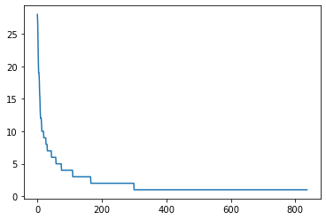

```python
import matplotlib.pyplot as plt
%matplotlib inline

w = [speech_word_count[key] for key in sorted_word_count]
plt.plot(w)
plt.show()
```

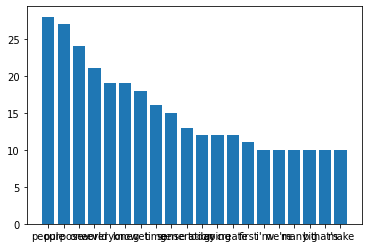

```python
n = sorted_word_count[:20]
w = [speech_word_count[key] for key in n]
plt.bar(range(len(n)),w,tick_label=n)
plt.show()
```

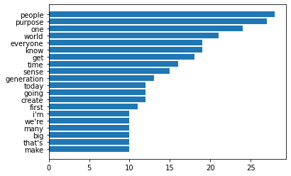

```python
n = sorted_word_count[:20][::-1]
w = [speech_word_count[key] for key in n]
plt.barh(range(len(n)),w,tick_label=n)
plt.show()
```

1. 워드 클라우드 그리기

```python
!pip install wordcloud
```

[figure not shown]

```python
from wordcloud import WordCloud

wordcloud = WordCloud().generate(doc_speech)

plt.axis("off")
plt.imshow(wordcloud, interpolation='bilinear')
plt.show()
```

워드클라우드를 통해 어떤 단어가 중요한지 단어의 크기별로 나타나는 것을 볼 수 있다.

```python
wordcloud.to_array().shape
```

```
(200, 400, 3)
```

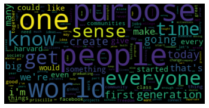

```python
wordcloud = WordCloud(max_font_size=60).generate_from_frequencies(speech_word_count)
plt.figure()
plt.axis("off")
plt.imshow(wordcloud, interpolation="bilinear")
plt.show()
```

자신의 해석

워드클라우드를 통해 하버드 대학에서 마크 주커버그의 연설에서 많이 사용한 단어는 'people', 'purpose', 'one', 'world', 'everyone' 등 임을 확인할 수 있습니다. '사람과 사람을 연결하면 비즈니스로 이어진다' 명언을 남길정도로 사람과 사람을 연결하는 것의 중요성에 대해 항상 이야기하는 마크 주커버그의 생각이 가장 많이 쓰인 단어 'people'로 잘 표현되었음을 확인할 수 있습니다. 특히, 'one', 'world', 'everyone' 등 같은 키워드는 세계 곳곳에서 하나의 공동체를 만드는 것에 대한 강조를 했다는 것을 알 수 있으며, 더 나아가 'purpose', 'everyone' 를 통해 모두가 의미를 갖는 최종 목적을 향해 함께 나아가 도전하는 것에 대한 의미로 해석할 수 있습니다. 페이스북 창업자이자 최고 경영자(CEO)인 마크 주커버그의 생각이 연설문을 통해 잘 나타났다고 생각합니다.